# Pipelines For Data Analysis In R, part 2

曾意儒 Yi-Ju Tseng

### 資料分析步驟

- **資料匯入**
- **資料清洗處理**並轉換為Tidy data
- 資料分析
- 資料呈現與視覺化

### 資料匯入

- 從檔案匯入
- 從網路匯入
- 從Twitter匯入
- 從Google Sheet匯入
- 資料匯出

## 從檔案匯入

- Import Dataset功能 (RStudio)
- R物件 .rds
- R程式 .R
- 純文字資料 (無分隔)
- 其他格式

### Import Dataset功能 (RStudio)

選取RStudio四分割視窗右上角的Environment標籤，選擇**Import Dataset**

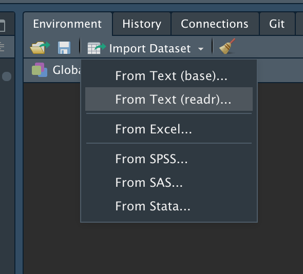

### Import Dataset功能 (RStudio)

- 選取`From Text (readr)`
- 點選`Browse`按鈕開啟檔案選取器

[figure not shown]

### Import Dataset功能 (RStudio)

- 利用下方`Import Options`的選項微調參數
  - `Delimiter`分隔符號
  - `First Row as Names`首列是否為欄位名稱

[figure not shown]

### Import Dataset功能 (RStudio)

- 操作[範例檔案](https://raw.githubusercontent.com/CGUIM-BigDataAnalysis/BigDataCGUIM/master/EMBA_BigData/f_lvr_land_a.csv)
- 若匯入的檔案為**tab分隔文字檔**? 該如何調整參數？

## R物件 .rds

如果在R程式內處理完資料後，必須儲存一份以供後續分析，使用R物件儲存是最佳的方式

- 檔案小
- 讀取快速
- 推薦使用`readRDS()`函數讀取RDS檔案
- [A better way of saving and loading objects in R](http://www.fromthebottomoftheheap.net/2012/04/01/saving-and-loading-r-objects/)

```r
dataset <- readRDS("檔案路徑與名稱")
```

## R程式 .R

- `source`函數
- 讀R的Obejct or script, **執行**
- **實際操作範例**
  - 有一份example.R檔在工作環境中
  - 一次執行檔案內所有R指令

```r
source("example.R")
```

## 純文字資料 (無分隔)

`readLines`, 逐行讀取文字資料

## 從網路匯入

- Open Data
- XML 可延伸標記式語言
- 網頁爬蟲 Webscraping
- API (Application programming interfaces)
- JSON格式檔案

## Open Data 開放資料

- 2011年推動開放政府與開放資料 ([維基百科](https://zh.wikipedia.org/wiki/%E9%96%8B%E6%94%BE%E8%B3%87%E6%96%99))
- 不受著作權、專利權，以及其他管理機制所限制，任何人都可以自由出版使用
- 常見的儲存方式為:
  - `CSV`
  - `JSON`
  - `XML`

### Open Data 開放資料常見平台

- [政府資料開放平台](https://data.gov.tw/)
- [Data Taipei](https://data.taipei/)
- [開放資料 x 開放桃園](https://data.tycg.gov.tw/)

## XML 可延伸標記式語言

- E**x**tensible **m**arkup **l**anguage
- 描述**結構化**資料的語言
- 處理XML檔案是網頁**Html**爬蟲的基礎
- Components
  - Markup 標記 - labels that give the text structure
  - Content 內文 - the actual text of the document
- [XML Wiki](https://zh.wikipedia.org/wiki/XML)

### XML 可延伸標記式語言

Tags, elements and attributes

- Tags correspond to general labels
  - Start tags `<breakfast_menu>`, `<price>`
  - End tags `</breakfast_menu>`,`</price>`
  - Empty tags `<line-break />`
- Elements are specific examples of tags
  - `<name>Belgian Waffles</name>`
- Attributes are components of the label
  - `<book category="web">`

### XML 可延伸標記式語言-讀取

- [空氣品質指標(AQI)](https://data.epa.gov.tw/api/v1/aqx_p_432?limit=1000&api_key=9be7b239-557b-4c10-9775-78cadfc555e9&format=xml)
- 安裝`xml2` package
- `read_xml()`函數將XML檔案匯入

```r
library(xml2)
AQIURL<-"https://data.epa.gov.tw/api/v2/aqx_p_432?api_key=e8dd42e6-9b8b-43f8-991e-b3dee723a52d&limit=1000&sort=ImportDate%20desc&format=XML"
AQIXML <- read_xml(AQIURL)
```

### xpath?

- XML路徑語言（XML Path Language）
- 基於XML的樹狀結構，提供在資料結構樹中找尋節點的能力
- [維基百科](https://zh.wikipedia.org/wiki/XPath)
- [常見語法](http://tech-marsw.logdown.com/blog/2016/01/11/parsing-lxml-xpath-sheet)

### XML 可延伸標記式語言-解析

使用`xml_find_all()`以及`xml_text()`函數取得指定標籤內的資料

```r
#取得所有"SiteName"標籤內的資料
SiteName_xml<-xml_find_all(AQIXML, ".//SITENAME")
SiteName<-xml_text(SiteName_xml)
SiteName[1:10]
```

```
 [1] "基隆" "汐止" "萬里" "新店" "土城" "板橋" "新莊" "菜寮" "林口" "淡水"
```

### XML 可延伸標記式語言-解析

使用`xml_find_all()`以及`xml_text()`函數取得指定標籤內的資料

```r
#取得各監測站的經度longitude
longitude_xml<-xml_find_all(AQIXML, ".//LONGITUDE")
longitude<-xml_text(longitude_xml)
longitude[1:10]
```

```
 [1] "121.760056"   "121.6423"     "121.689881"   "121.537778"   "121.451861"
 [6] "121.458667"   "121.4325"     "121.481028"   "121.36548982" "121.449239"
```

### XML檔案匯入練習

- 載入[農產品交易行情](https://data.coa.gov.tw/Service/OpenData/FromM/FarmTransData.aspx?FOTT=Xml)
- 嘗試取得各筆交易的作物名稱與平均價
- 參考剛剛的AQI範例

```r
library(xml2)
AQIURL<-"https://data.epa.gov.tw/api/v2/aqx_p_432?api_key=e8dd42e6-9b8b-43f8-991e-b3dee723a52d&limit=1000&sort=ImportDate%20desc&format=XML"
AQIXML <- read_xml(AQIURL)
SiteName_xml<-xml_find_all(AQIXML, ".//SITENAME")
SiteName<-xml_text(SiteName_xml)
SiteName[1:10]
```

## API

- 應用程式介面
- **A**pplication **P**rogramming **I**nterfaces
- 為了讓第三方的開發者可以額外開發應用程式來強化他們的產品，推出可以與系統溝通的介面
- 有API輔助可將資料擷取過程自動化
  - 以下載Open Data為例，若檔案更新頻繁，使用手動下載相當耗時
- [維基百科](https://zh.wikipedia.org/zh-tw/%E5%BA%94%E7%94%A8%E7%A8%8B%E5%BA%8F%E6%8E%A5%E5%8F%A3)

### API - Open Data

- [桃園公共自行車即時服務資料](http://data.tycg.gov.tw/opendata/datalist/datasetMeta?oid=5ca2bfc7-9ace-4719-88ae-4034b9a5a55c)資料
- 每日更新
- 不可能每日手動下載
- 提供透過**API**下載的服務
- 透過API下載的資料格式: **JSON格式**
- [桃園公共自行車即時服務資料API資訊](http://data.tycg.gov.tw/opendata/datalist/datasetMeta/outboundDesc?id=5ca2bfc7-9ace-4719-88ae-4034b9a5a55c&rid=a1b4714b-3b75-4ff8-a8f2-cc377e4eaa0f)
  - **資料集ID**: 紀錄資料的基本參數，如包含欄位、更新頻率等
  - **資料RID**: 資料集
  - 擷取範例

## JSON格式檔案

- JSON (**J**ava**s**cript **O**bject **N**otation)
- 輕量級的資料交換語言
- From **a**pplication **p**rogramming **i**nterfaces (APIs)
- JavaScript、Java、Node.js應用
- 一些NoSQL資料庫用JSON儲存資料：**MongoDB**
- [Wiki](http://en.wikipedia.org/wiki/JSON)

### JSON檔案匯入

- `jsonlite` package (套件使用前必須安裝)
- `fromJSON()`函數載入JSON資料
- 如果API網址為**https**，則需使用 `httr` package
  - 使用`GET()`函數處理資料擷取網址
- API網址參考[桃園公共自行車即時服務資料API資訊](http://data.tycg.gov.tw/opendata/datalist/datasetMeta/outboundDesc?id=5ca2bfc7-9ace-4719-88ae-4034b9a5a55c&rid=a1b4714b-3b75-4ff8-a8f2-cc377e4eaa0f)

```r
library(jsonlite)
APIData<-fromJSON("http://data.tycg.gov.tw/api/v1/rest/datastore/a1b4714b-3b75-4ff8-a8f2-cc377e4eaa0f?format=json")
```

### JSON檔案匯入

- 轉存為`列表list`的型態
- 兩個子元素(success, result)
- result中records子元素的類別為資料框data.frame

```r
str(APIData)
```

```
List of 2
 $ success: logi TRUE
 $ result :List of 8
  ..$ include_total : logi TRUE
  ..$ resource_id   : chr "a1b4714b-3b75-4ff8-a8f2-cc377e4eaa0f"
  ..$ fields        :'data.frame':  15 obs. of  2 variables:
  .. ..$ type: chr [1:15] "int" "text" "text" "text" ...
  .. ..$ id  : chr [1:15] "_id" "sno" "sna" "tot" ...
  ..$ records_format: chr "objects"
  ..$ records       :'data.frame':  100 obs. of  15 variables:
  .. ..$ _id    : int [1:100] 1 2 3 4 5 6 7 8 9 10 ...
  .. ..$ sno    : chr [1:100] "2001" "2002" "2003" "2004" ...
  .. ..$ sna    : chr [1:100] "中央大學圖書館" "中壢高中" "中正公園(中美路)" "中壢火車站(前站)" ...
  .. ..$ tot    : chr [1:100] "60" "52" "54" "94" ...
  .. ..$ sbi    : chr [1:100] "36" "30" "11" "33" ...
  .. ..$ sarea  : chr [1:100] "中壢區" "中壢區" "中壢區" "中壢區" ...
  .. ..$ mday   : chr [1:100] "20221209114226" "20221209114242" "20221209114250" "20221209114224" ...
  .. ..$ lat    : chr [1:100] "24.968128" "24.960815" "24.959113" "24.954042" ...
  .. ..$ lng    : chr [1:100] "121.194666" "121.212038" "121.224805" "121.22644" ...
  .. ..$ ar     : chr [1:100] "中大路300號(中央大學校內圖書館前)" "中央西路二段215號對面人行道" "中美路101-113號對面人行道" "中和路109號空地" ...
  .. ..$ sareaen: chr [1:100] "Zhongli Dist." "Zhongli Dist." "Zhongli Dist." "Zhongli Dist." ...
  .. ..$ snaen  : chr [1:100] "National Central University Library" "Jhungli Senior High School" "Zhongzheng Park (Zhongmei Rd.)" "TRA Zhongli Station (Front)" ...
  .. ..$ aren   : chr [1:100] "No.300, Zhongda Rd." "No.215, Sec. 2, Zhongyang W. Rd. (opposite)" "No.101 to No.113, Zhongmei Rd. (opposite)" "No. 109, Zhonghe Rd." ...
  .. ..$ bemp   : chr [1:100] "23" "22" "43" "58" ...
  .. ..$ act    : chr [1:100] "1" "1" "1" "1" ...
  ..$ offset        : int 0
  ..$ total         : int 400
  ..$ limit         : int 100
```

### JSON檔案解析

- 使用`$`符號截取元素與子元素

```r
head(APIData$result$records)
```

| _id | sno | sna | tot | sbi | sarea | mday | lat | lng |
| --- | --- | --- | --- | --- | --- | --- | --- | --- |
| 1 | 2001 | 中央大學圖書館 | 60 | 36 | 中壢區 | 20221209114226 | 24.968128 | 121.194666 |
| 2 | 2002 | 中壢高中 | 52 | 30 | 中壢區 | 20221209114242 | 24.960815 | 121.212038 |
| 3 | 2003 | 中正公園(中美路) | 54 | 11 | 中壢區 | 20221209114250 | 24.959113 | 121.224805 |
| 4 | 2004 | 中壢火車站(前站) | 94 | 33 | 中壢區 | 20221209114224 | 24.954042 | 121.22644 |
| 5 | 2005 | 中原大學 | 82 | 45 | 中壢區 | 20221209114218 | 24.957943 | 121.240201 |
| 6 | 2006 | 銀河廣場 | 58 | 13 | 中壢區 | 20221209114239 | 24.961716 | 121.224241 |
| 7 | 2007 | 中壢區公所 | 40 | 14 | 中壢區 | 20221209114224 | 24.965697 | 121.224696 |
| 8 | 2008 | 光明公園 | 96 | 64 | 中壢區 | 20221209114229 | 24.962812 | 121.217385 |

### JSON檔案解析

分析各項**地區**車站數

```r
table(APIData$result$records$sarea)
```

| Var1 | Freq |
| --- | --- |
| 中壢區 | 35 |
| 八德區 | 5 |
| 大園區 | 2 |
| 大溪區 | 2 |
| 平鎮區 | 7 |
| 桃園區 | 32 |
| 蘆竹區 | 7 |
| 龜山區 | 10 |

分析可知中壢區車站較多

### JSON檔案匯入練習

- 練習用資料：[桃園市路外停車資訊](https://data.tycg.gov.tw/opendata/datalist/datasetMeta/download?id=f4cc0b12-86ac-40f9-8745-885bddc18f79&rid=0daad6e6-0632-44f5-bd25-5e1de1e9146f)
- 使用檔案匯入**範例**，將資料匯入R中
  - 提示：**fromJSON**
- 使用str()函數觀察匯入的資料
- 請問有幾筆觀察值？幾個欄位？

## 網頁爬蟲 Webscraping

- 不是每個網站都提供API
- 人工複製貼上?!
- 程式化的方式擷取網頁資料: **網頁爬蟲（Webscraping）**（[Webscraping Wiki](http://en.wikipedia.org/wiki/Web_scraping)）
- 可能耗費很多網頁流量和資源 －很可能被鎖IP
- 在R的處理辦法
  - 當作XML檔案處理分析
  - 使用`rvest` package輔助

### 網頁爬蟲 Webscraping-rvest

載入rvest套件後，經由以下步驟進行網站解析：

- 使用`read_html(“欲擷取的網站網址”)`函數讀取網頁
- 使用`html_nodes()`函數擷取所需內容 (條件為CSS或xpath標籤)
- 使用`html_text()`函數處理/清洗擷取內容，留下需要的資料
- 使用`html_attr()`函數擷取資料參數（如連結url）

### 網頁爬蟲 Webscraping-rvest

```r
library(rvest) ##載入
Repoterurl<-"https://www.twreporter.org/topics"
Repoterhtml<-read_html(Repoterurl)
news_title <- Repoterhtml %>%
    html_nodes(".eIzpqT") %>% html_text()
news_title
```

```
[1] "那些縫補中的家庭，與他們的孩子──台灣兒少安置現況與未竟之事"
[2] "1978，請回答──亡國感下台灣主體藝文的追尋與迴聲"
[3] "夢想、政治、金權──世界盃的追求"
[4] "地方政治的提升與倒退？"
[5] "金馬59 | 凝視傷疤：幽暗之眼與一瞬之光"
```

### 網頁爬蟲 Webscraping-rvest

- 擷取條件的撰寫會因網頁語法不同而有差異
- 使用**Google Chrome開發工具**輔助觀察擷取資料的條件
  - 或使用**SelectorGadget**輔助
  - 或使用**xpath-helper**輔助xpath標籤的擷取
- 觀察需要擷取的資料所在HTML片段
  - css class為`.eIzpqT`

### 盤中奈米股資料爬取 -1

[零股資料](https://fubon-ebrokerdj.fbs.com.tw/z/ze/zeg/zega_EBTW50E_I.djhtm)

```r
library(rvest)
NanoStockUrl<-"https://fubon-ebrokerdj.fbs.com.tw/z/ze/zeg/zega_EBTW50E_I.djhtm"
NanoStockContent<-read_html(NanoStockUrl)
NanoStockName<-
  NanoStockContent %>% html_nodes("#oAddCheckbox") %>% html_text()
NanoStockPrice<-
  NanoStockContent %>% html_nodes(".t3n1")%>% html_text()

head(NanoStockName)
```

```
[1] "\r\n\r\n<!--\r\n\tGenLink2stk('AS1101','台泥');\r\n//-->\r\n"
[2] "\r\n\r\n<!--\r\n\tGenLink2stk('AS1216','統一');\r\n//-->\r\n"
[3] "\r\n\r\n<!--\r\n\tGenLink2stk('AS1301','台塑');\r\n//-->\r\n"
[4] "\r\n\r\n<!--\r\n\tGenLink2stk('AS1303','南亞');\r\n//-->\r\n"
[5] "\r\n\r\n<!--\r\n\tGenLink2stk('AS1326','台化');\r\n//-->\r\n"
[6] "\r\n\r\n<!--\r\n\tGenLink2stk('AS1402','遠東新');\r\n//-->\r\n"
```

```r
head(NanoStockPrice)
```

```
[1] "34.25"     "157,526"   "231"       "34.25"     "12,330"    "5,413,777"
```

### 盤中奈米股資料爬取 -2

```r
NanoStockPriceTable<-
  matrix(NanoStockPrice,ncol=6, byrow=TRUE)
NanoStockNameClean<-gsub('\\r|<|!|\\n|\\t|GenLink2stk|;|/|-|>',
                         '',
                         NanoStockName)
NanoStockData <-
    data.frame(name = NanoStockNameClean,
               NanoStockPriceTable)
```

### 盤中奈米股資料爬取 -3

```r
NanoStockData
```

| name | X1 | X2 | X3 | X4 | X5 | X6 |
| --- | --- | --- | --- | --- | --- | --- |
| ('AS1101','台泥') | 34.25 | 157,526 | 231 | 34.25 | 12,330 | 5,413,777 |
| ('AS1216','統一') | 65.80 | 8,118 | 133 | 65.80 | 2,840 | 533,696 |
| ('AS1301','台塑') | 87.00 | 45,726 | 178 | 87.00 | 3,769 | 3,943,609 |
| ('AS1303','南亞') | 70.80 | 26,749 | 187 | 70.80 | 5,410 | 1,893,381 |
| ('AS1326','台化') | 69.80 | 14,716 | 142 | 69.90 | 1,872 | 1,026,298 |
| ('AS1402','遠東新') | 31.75 | 24,361 | 162 | 31.80 | 2,571 | 772,114 |
| ('AS1590','亞德客KY') | 915.00 | 1,065 | 32 | 911.00 | 5 | 966,589 |
| ('AS2002','中鋼') | 30.65 | 103,267 | 239 | 30.65 | 14,347 | 3,147,799 |
| ('AS2207','和泰車') | 596.00 | 2,307 | 84 | 596.00 | 56 | 1,358,852 |
| ('AS2303','聯電') | 42.00 | 126,587 | 237 | 42.00 | 8,570 | 5,319,658 |
| ('AS2308','台達電') | 283.00 | 79,023 | 223 | 283.50 | 2,128 | 22,239,664 |
| ('AS2317','鴻海') | 101.00 | 94,100 | 256 | 101.00 | 14,369 | 9,487,422 |
| ('AS2327','國巨') | 461.50 | 24,883 | 171 | 460.00 | 4,182 | 11,420,178 |
| ('AS2330','台積電') | 455.50 | 1,796,740 | 261 | 457.00 | 45,413 | 820,558,419 |
| ('AS2357','華碩') | 273.00 | 13,648 | 174 | 272.00 | 1,476 | 3,712,197 |
| ('AS2379','瑞昱') | 298.00 | 9,401 | 136 | 292.00 | 100 | 2,723,866 |
| ('AS2382','廣達') | 71.90 | 16,227 | 182 | 71.70 | 1,414 | 1,155,701 |
| ('AS2395','研華') | 334.50 | 1,632 | 84 | 332.00 | 732 | 540,577 |
| ('AS2408','南亞科') | 54.60 | 23,674 | 147 | 51.30 | 1,138 | 1,211,868 |
| ('AS2412','中華電') | 113.00 | 23,032 | 171 | 113.00 | 4,656 | 2,588,144 |
| ('AS2454','聯發科') | 662.00 | 39,663 | 244 | 662.00 | 2,097 | 26,031,789 |
| ('AS2603','長榮') | 167.00 | 156,224 | 250 | 167.50 | 33,409 | 26,058,553 |
| ('AS2609','陽明') | 67.50 | 116,508 | 230 | 67.60 | 6,877 | 7,832,024 |
| ('AS2615','萬海') | 86.10 | 127,870 | 243 | 86.20 | 16,726 | 10,894,336 |
| ('AS2801','彰銀') | 17.30 | 7,795 | 89 | 17.25 | 3,873 | 134,692 |
| ('AS2880','華南金') | 22.60 | 41,334 | 172 | 22.60 | 6,766 | 935,452 |
| ('AS2881','富邦金') | 56.90 | 51,517 | 204 | 56.80 | 11,692 | 2,922,216 |
| ('AS2882','國泰金') | 41.15 | 130,329 | 230 | 41.15 | 27,527 | 5,351,083 |
| ('AS2883','開發金') | 12.80 | 47,260 | 191 | 12.75 | 12,429 | 603,616 |
| ('AS2884','玉山金') | 24.25 | 117,939 | 239 | 24.25 | 13,933 | 2,852,065 |
| ('AS2885','元大金') | 21.90 | 103,102 | 193 | 21.90 | 9,897 | 2,251,812 |
| ('AS2886','兆豐金') | 30.70 | 125,985 | 250 | 30.70 | 7,613 | 3,856,913 |
| ('AS2887','台新金') | 15.20 | 59,500 | 207 | 15.20 | 12,632 | 901,717 |
| ('AS2890','永豐金') | 16.80 | 173,027 | 233 | 16.75 | 12,380 | 2,907,750 |
| ('AS2891','中信金') | 22.10 | 81,832 | 225 | 22.00 | 6,516 | 1,795,586 |
| ('AS2892','第一金') | 26.30 | 37,840 | 207 | 26.35 | 8,547 | 995,774 |
| ('AS2912','統一超') | 270.00 | 10,062 | 158 | 270.00 | 1,524 | 2,705,095 |
| ('AS3008','大立光') | 2,140.00 | 9,418 | 196 | 2,140.00 | 288 | 20,087,415 |
| ('AS3034','聯詠') | 302.00 | 17,499 | 179 | 302.00 | 1,910 | 5,255,486 |
| ('AS3037','欣興') | 125.00 | 105,892 | 233 | 125.00 | 9,429 | 13,090,096 |
| ('AS3045','台灣大') | 94.70 | 6,304 | 106 | 94.80 | 1,894 | 595,134 |
| ('AS3711','日月光投控') | 94.50 | 65,331 | 217 | 94.20 | 2,310 | 6,143,494 |
| ('AS4904','遠傳') | 66.80 | 14,827 | 141 | 65.80 | 1,732 | 976,718 |
| ('AS5871','中租KY') | 216.00 | 31,371 | 173 | 216.00 | 2,553 | 6,771,626 |
| ('AS5876','上海商銀') | 44.35 | 18,314 | 122 | 44.35 | 3,521 | 808,507 |
| ('AS5880','合庫金') | 26.05 | 57,646 | 217 | 26.15 | 6,589 | 1,501,704 |
| ('AS6415','矽力*KY') | 450.00 | 5,878 | 118 | 442.00 | 1,092 | 2,596,635 |
| ('AS6505','台塑化') | 82.80 | 8,888 | 117 | 80.10 | 1,167 | 712,809 |
| ('AS8046','南電') | 244.00 | 30,752 | 198 | 242.00 | 3,294 | 7,420,091 |
| ('AS9910','豐泰') | 208.00 | 10,896 | 136 | 207.50 | 345 | 2,268,749 |

### 爬蟲練習

- [Ptt Tech_Job 版](https://www.ptt.cc/bbs/Tech_Job/index.html)
- 試著爬出所有**標題**
- 爬出的第三個標題是？

### 網頁爬蟲 再想想？

- 其實… 很多資料有其他存取方式，像API
  - https://www.dcard.tw/_api/forums/cgu/posts
  - https://www.dcard.tw/_api/posts/225917717
  - https://www.dcard.tw/_api/posts/225917717/comments
- 隱私問題 （OkCupid事件）
  - [70,000 OkCupid Users Just Had Their Data Published](https://motherboard.vice.com/en_us/article/70000-okcupid-users-just-had-their-data-published)

### 進階爬蟲

- CSS Selector 語法介紹 [參考資料](https://www.w3schools.com/cssref/css_selectors.asp)
  - **.**xxx：select elements with class=“xxx”
  - **#**xxx：select elements with id=“xxx”
  - **[**yyy**]**：select elements with attribute yyy
  - **[**yyy=zzz**]**：select elements with attribute yyy=“zzz”
- 瀑布式網頁爬蟲
  - 觀察Google Chrome 開發者工具，在Network內找到api呼叫方式
  - 搭配使用RSelenium 模擬瀏覽狀態 [DCard實作R Code](https://github.com/CGUIM-BigDataAnalysis/BigDataCGUIM/blob/master/105/RSelenium_rvest.md)

### 其他爬蟲相關參考資源

- [網路爬蟲實作 - 用 r 語言打造自己的爬蟲程式](https://www.slideshare.net/secret/mdfHLPgvIW1kPR)
- [rvest GitHub](https://github.com/tidyverse/rvest)
- R Bloggers 有很多[爬蟲範例](http://www.r-bloggers.com/?s=Web+Scraping)（英文）
- [Ptt爬蟲實作](http://bryannotes.blogspot.tw/2014/08/r-ptt-wantedsocial-network-analysis.html)
- [大數學堂 網頁爬蟲課程](http://www.largitdata.com/course_list/1)

## 從Facebook匯入

- Graph API in R
- Rfacebook package

## Graph API in R

- 在2018年的風波後，Graph API若要用在爬取公開粉專，須經過FB審核
- [Graph API](https://developers.facebook.com/docs/graph-api?locale=zh_TW)
  - 根據篩選條件，回傳JSON格式的資料
- [Graph API Explorer](https://developers.facebook.com/tools/explorer/)
  - 測試資料撈取方法和結果
- 必須要取得自己的**access token** (存取權杖)
  - 可在[Graph API Explorer](https://developers.facebook.com/tools/explorer/)視窗右上角的**Get Token**按鈕取得
  - [官方文件](https://developers.facebook.com/docs/facebook-login/access-tokens/?locale=zh_TW)

## Rfacebook package

在2018年的風波後，Graph API若要用在爬取公開粉專，須經過FB審核，因此本課程目前無法示範粉絲專頁爬取

使用 Rfacebook 取得 `tsaiingwen` 粉絲頁的資料

```r
library(Rfacebook) #初次使用須先安裝
token<-"your token" #將token複製到此處
getPage("tsaiingwen", token,n = 5)
```

若經過審核，可得下列結果

```
4 posts       from_id           from_name
1 46251501064 蔡英文 Tsai Ing-wen
2 46251501064 蔡英文 Tsai Ing-wen
3 46251501064 蔡英文 Tsai Ing-wen
4 46251501064 蔡英文 Tsai Ing-wen
```

## 從Twitter匯入

- Twitter API
- rtweet package

### Twitter API

- https://developer.twitter.com/en/apps
- 需有Twitter帳號並通過開發者審核

### rtweet package

```r
## install rtweet from CRAN
install.packages("rtweet")
## load rtweet package
library(rtweet)
```

### rtweet package - token 設定

```r
library(rtweet)
create_token(
  app = "teach0309",
  consumer_key = "Wbba6ysyPKGstGAqohmtyWZOE",
  consumer_secret = "GJweDzVvXGrbjz26bHTr3d6dFI7q9gFCH98f3Ct2yk3APPWigc",
  access_token = "216362944-AxxvSiPBR7nBScfBks7thajSovUwFG6v67aNR3WP",
  access_secret = "pF0OldOjiJxaBbPlQhx7V3VkA6MIgdzHHofar1DM0pX0G")
```

### rtweet package - 搜尋hashtag

```r
## search for 3000 tweets using the Taiwan hashtag
rt <- search_tweets(
  "#Taiwan", n = 3000, include_rts = FALSE
)
head(rt)
```

| created_at | id | id_str | full_text |
| --- | --- | --- | --- |
| 2022-12-23 18:33:07 | 1.606236e+18 | 1606236454769725441 | Grateful to the members of #Taiwan’s armed forces for all they do to defend our nation. This Christmas, we reaffirm our commitment to providing them with the living & training environment they need to… |
| 2022-12-23 05:47:14 | 1.606044e+18 | 1606043712873566208 | While much of the attention of the public, #NATSEC analysts and journalists has been rightly on the visit of @ZelenskyyUa to Washington DC, we should not forget the Chinese aggression around #Taiwan. … |
| 2022-12-23 11:35:34 | 1.606131e+18 | 1606131371247751169 | Congrats to #Taiwanese photographer Wang Chen-che (王呈哲), who won nine gold medals at the New York Photography Awards for three of his photographic works! The gold-winning pieces are images of temples … |
| 2022-12-24 11:30:06 | 1.606492e+18 | 1606492385353269248 | #Taiwan #AQI #Yunlin #Mailiao 雲林麥寮, 良好, 主要污染: 無, 空氣品質指標: 50, PM2.5: 15, PM10: 74, 更新時間: 2022/12/24 11:00:00 |
| 2022-12-24 11:30:06 | 1.606492e+18 | 1606492384636063745 | #Taiwan #AQI #Kaohsiung #Xiaogang 高雄小港, 普通, 主要污染: 細懸浮微粒, 空氣品質指標: 88, PM2.5: 28, PM10: 52, 更新時間: 2022/12/24 11:00:00 |
| 2022-12-24 11:30:06 | 1.606492e+18 | 1606492383935627265 | #Taiwan #AQI #Taichung #Xitun 臺中西屯, 良好, 主要污染: 無, 空氣品質指標: 33, PM2.5: 9, PM10: 31, 更新時間: 2022/12/24 11:00:00 |

### rtweet package - 搜尋hashtag

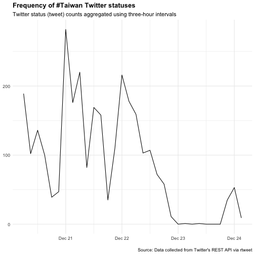

### rtweet package - 取得趨勢

```r
sf <- get_trends("USA")
head(sf)
```

[output not shown]

### rtweet package - 取得timeline

```r
tmls_Bezos <- get_timelines("JeffBezos", n = 1000)
tmls_Musk <- get_timelines( "elonmusk", n = 1000)
head(tmls_Bezos)
head(tmls_Musk)
```

| full_text | source |
| --- | --- |
| This year’s Bezos Day 1 Families Fund grants go to 40 incredible groups working to end homelessness in the U.S. In 5 years, we’ve given more than $500 million to 167 orgs – helping expand their suppor… | [Twitter for iPhone](http://twitter.com/download/iphone) |
| RT @awscloud: .@Werner is pulling back the curtain on #Amazon history with the Distributed Computing Manifesto. |  |

| full_text | source |
| --- | --- |
| @cyrusrezvanian @christine_rez Almost no one understands | [Twitter for iPhone](http://twitter.com/download/iphone) |
| @tobi You can also now play all Steam games on the latest Model S/X cars | [Twitter for iPhone](http://twitter.com/download/iphone) |
| @BillFOXLA @FoxNews !! | [Twitter for iPhone](http://twitter.com/download/iphone) |
| @PranavHegdeHere That and several major UI improvements coming in Jan | [Twitter for iPhone](http://twitter.com/download/iphone) |
| @CollinRugg To be clear, I am overall very much pro FBI. The agency does a great deal of important work protecting the public. |  |

### rtweet package - 取得timeline

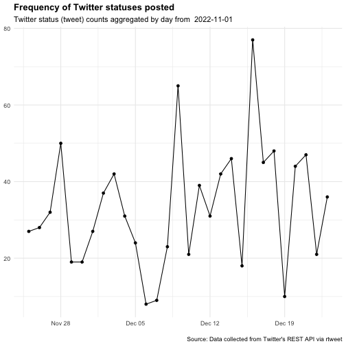

### rtweet package - favorites

```r
## get user IDs of accounts favorited by Elon Musk
em_flw <- get_favorites("elonmusk", n = 100)
head(em_flw)
```

| text | created_at | id_str |
| --- | --- | --- |
| Code is a liability, not an asset. So goal of software engineer is delivering the maximum amount of desired functionality at the cost of the least amount of code complexity, even as desired functional… | 2022-12-24 11:03:42 | 1606485739679932416 |
| We wish you a Merry Christmas 🎶 |  |  |

### rtweet package練習

- 複製老師的Twitter access token
- 使用rtweet package取得**蔡英文 Tsai Ing-wen**(iingwen)的timeline，共50筆tweets
- 第一筆資料的retweet_count是多少?
- 第二筆資料的favorite_count是多少?

## 從Google sheet匯入

- googlesheets4 package

### googlesheets4 package

```r
## install googlesheets4 from CRAN (already included in tidyverse)
install.packages("googlesheets4")
## load googlesheets4 package
library(googlesheets4)
```

### googlesheets4 package

使用`read_sheet()`讀入[範例google sheet](https://docs.google.com/spreadsheets/d/13gnwAUXaxHATsZIGO3mPtdxLMxseE1oYNjgTV4tdFkk/edit#gid=0)

```r
read_sheet("https://docs.google.com/spreadsheets/d/13gnwAUXaxHATsZIGO3mPtdxLMxseE1oYNjgTV4tdFkk/edit#gid=0")
```

```
# A tibble: 14 × 7
    學號 作業一 ...3  ...4  ...5  心得一 心得二
   <dbl> <chr>  <lgl> <lgl> <lgl> <chr>  <chr>
 1     1 O      NA    NA    NA    <NA>   <NA>
 2     2 O      NA    NA    NA    O      <NA>
 3     3 O      NA    NA    NA    O      O
 4     4 O      NA    NA    NA    O      <NA>
 5     5 O      NA    NA    NA    O      <NA>
 6     6 O      NA    NA    NA    <NA>   <NA>
 7     7 O      NA    NA    NA    <NA>   <NA>
 8     8 O      NA    NA    NA    <NA>   <NA>
 9     9 O      NA    NA    NA    O      <NA>
10    10 O      NA    NA    NA    O      <NA>
11    11 O      NA    NA    NA    O      <NA>
12    12 O      NA    NA    NA    <NA>   <NA>
13    13 O      NA    NA    NA    <NA>   <NA>
14    14 O      NA    NA    NA    <NA>   <NA>
```

### 需要開啟google 授權

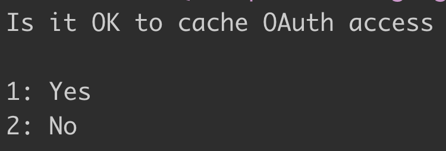

[figure not shown]

### googlesheets4 package

使用`read_sheet()`讀入[範例google sheet](https://docs.google.com/spreadsheets/d/13gnwAUXaxHATsZIGO3mPtdxLMxseE1oYNjgTV4tdFkk/edit#gid=0)

```r
read_sheet("https://docs.google.com/spreadsheets/d/13gnwAUXaxHATsZIGO3mPtdxLMxseE1oYNjgTV4tdFkk/edit#gid=0")
```

| 學號 | 作業一 | …3 | …4 | …5 | 心得一 | 心得二 |
| --- | --- | --- | --- | --- | --- | --- |
| 1 | O | NA | NA | NA | NA | NA |
| 2 | O | NA | NA | NA | O | NA |
| 3 | O | NA | NA | NA | O | O |
| 4 | O | NA | NA | NA | O | NA |
| 5 | O | NA | NA | NA | O | NA |
| 6 | O | NA | NA | NA | NA | NA |
| 7 | O | NA | NA | NA | NA | NA |
| 8 | O | NA | NA | NA | NA | NA |
| 9 | O | NA | NA | NA | O | NA |
| 10 | O | NA | NA | NA | O | NA |
| 11 | O | NA | NA | NA | O | NA |
| 12 | O | NA | NA | NA | NA | NA |
| 13 | O | NA | NA | NA | NA | NA |
| 14 | O | NA | NA | NA | NA | NA |

## 資料匯出

- 文字檔 .txt
- CSV檔 .csv
- R物件 .rds

## 文字檔 .txt write.table()

```r
write.table(iris,file="iris.txt",sep=",",
            row.names = F,col.names = T)
```

- 要匯出的資料
- `file` 檔案名稱
- `append` T/F T:在檔案後加字，F:直接覆蓋檔案 (預設F)
- `quote` 是否需要用雙引號將字串包起 (預設T)
- `sep` 分隔符號 (預設空白)
- `row.names` T/F 是否需要輸出row names
- `col.names` T/F 是否需要輸出column names
- `fileEncoding` 編碼設定

## CSV檔 .csv

與`write.table()`類似，使用`write.csv()`函數寫入檔案

```r
write.csv(iris,file="iris.csv",row.names = F)
```

## R物件 .rds

若是要在R的環境繼續使用，建議匯出成R物件檔案(.rds)

```r
saveRDS(iris,"iris.rds")
```

### 資料清洗與處理

- Tidy Data
- 資料型別轉換處理
- 文字字串處理
- 子集Subset
- 排序
- 資料組合
- 長表轉寬表
- 遺漏值處理

## Tidy Data

Each column is a variable. Each row is an observation.

- 一個欄位（Column）內只有一個數值，最好要有凡人看得懂的Column Name
- 不同的觀察值應該要在不同列（Row）
- 一張表裡面，有所有分析需要的資料
- 如果一定要多張表，中間一定要有index可以把表串起來
- One file, one table

## 資料型別轉換處理

包括**資料型別檢查**與**資料型別轉換**

資料型別:

- 數值 (numeric)
- 字串 (character)
- 布林變數 (logic)
- 日期 (Date)

### 資料型別檢查 - is.

使用`is.`函數檢查資料型別，回傳布林變數，若為**真**，回傳**TRUE**

- 是否為**數字** `is.numeric(變數名稱)`
- 是否為**文字** `is.character(變數名稱)`
- 是否為**布林變數** `is.logical(變數名稱)`

```r
num<-100
is.numeric(num)
```

```
[1] TRUE
```

```r
is.character(num)
```

```
[1] FALSE
```

### 資料型別檢查 - class()

使用`class(變數名稱)`函數，直接回傳**資料型別**

```r
class(num)
```

```
[1] "numeric"
```

```r
class(Sys.Date())
```

```
[1] "Date"
```

### 資料型別轉換 - as.

使用`as.`函數轉換型別

- 轉換為**數字** `as.numeric(變數名稱)`
- 轉換為**文字** `as.character(變數名稱)`
- 轉換為**布林變數** `as.logical(變數名稱)`

```r
cha<-"100"
as.numeric(cha)
```

```
[1] 100
```

### 資料型別轉換 - as.

若無法順利完成轉換，會回傳空值`NA`，並出現警告訊息

```r
as.numeric("abc")
```

```
[1] NA
```

### 資料型別轉換練習

回想起奈米股盤中交易的資料．．．

```r
library(rvest)
NanoStockUrl<-"https://fubon-ebrokerdj.fbs.com.tw/z/ze/zeg/zega_EBTW50E_I.djhtm"
NanoStockContent<-read_html(NanoStockUrl)
NanoStockName<-
  NanoStockContent %>% html_nodes("#oAddCheckbox") %>%
    html_text()
NanoStockPrice<-
  NanoStockContent %>% html_nodes(".t3n1")%>%
    html_text()
NanoStockPriceTable<-
  matrix(NanoStockPrice,ncol=6, byrow=TRUE)
NanoStockNameClean<-gsub('\\r|<|!|\\n|\\t|GenLink2stk|;|/|-|>',
                         '',
                         NanoStockName)
NanoStockData <-
    data.frame(name = NanoStockNameClean,
               NanoStockPriceTable)
knitr::kable(NanoStockData)
```

| name | X1 | X2 | X3 | X4 | X5 | X6 |
| --- | --- | --- | --- | --- | --- | --- |
| ('AS1101','台泥') | 34.25 | 157,526 | 231 | 34.25 | 12,330 | 5,413,777 |
| ('AS1216','統一') | 65.80 | 8,118 | 133 | 65.80 | 2,840 | 533,696 |
| ('AS1301','台塑') | 87.00 | 45,726 | 178 | 87.00 | 3,769 | 3,943,609 |
| ('AS1303','南亞') | 70.80 | 26,749 | 187 | 70.80 | 5,410 | 1,893,381 |
| ('AS1326','台化') | 69.80 | 14,716 | 142 | 69.90 | 1,872 | 1,026,298 |
| ('AS1402','遠東新') | 31.75 | 24,361 | 162 | 31.80 | 2,571 | 772,114 |
| ('AS1590','亞德客KY') | 915.00 | 1,065 | 32 | 911.00 | 5 | 966,589 |
| ('AS2002','中鋼') | 30.65 | 103,267 | 239 | 30.65 | 14,347 | 3,147,799 |
| ('AS2207','和泰車') | 596.00 | 2,307 | 84 | 596.00 | 56 | 1,358,852 |
| ('AS2303','聯電') | 42.00 | 126,587 | 237 | 42.00 | 8,570 | 5,319,658 |
| ('AS2308','台達電') | 283.00 | 79,023 | 223 | 283.50 | 2,128 | 22,239,664 |
| ('AS2317','鴻海') | 101.00 | 94,100 | 256 | 101.00 | 14,369 | 9,487,422 |
| ('AS2327','國巨') | 461.50 | 24,883 | 171 | 460.00 | 4,182 | 11,420,178 |
| ('AS2330','台積電') | 455.50 | 1,796,740 | 261 | 457.00 | 45,413 | 820,558,419 |
| ('AS2357','華碩') | 273.00 | 13,648 | 174 | 272.00 | 1,476 | 3,712,197 |
| ('AS2379','瑞昱') | 298.00 | 9,401 | 136 | 292.00 | 100 | 2,723,866 |
| ('AS2382','廣達') | 71.90 | 16,227 | 182 | 71.70 | 1,414 | 1,155,701 |
| ('AS2395','研華') | 334.50 | 1,632 | 84 | 332.00 | 732 | 540,577 |
| ('AS2408','南亞科') | 54.60 | 23,674 | 147 | 51.30 | 1,138 | 1,211,868 |
| ('AS2412','中華電') | 113.00 | 23,032 | 171 | 113.00 | 4,656 | 2,588,144 |
| ('AS2454','聯發科') | 662.00 | 39,663 | 244 | 662.00 | 2,097 | 26,031,789 |
| ('AS2603','長榮') | 167.00 | 156,224 | 250 | 167.50 | 33,409 | 26,058,553 |
| ('AS2609','陽明') | 67.50 | 116,508 | 230 | 67.60 | 6,877 | 7,832,024 |
| ('AS2615','萬海') | 86.10 | 127,870 | 243 | 86.20 | 16,726 | 10,894,336 |
| ('AS2801','彰銀') | 17.30 | 7,795 | 89 | 17.25 | 3,873 | 134,692 |
| ('AS2880','華南金') | 22.60 | 41,334 | 172 | 22.60 | 6,766 | 935,452 |
| ('AS2881','富邦金') | 56.90 | 51,517 | 204 | 56.80 | 11,692 | 2,922,216 |
| ('AS2882','國泰金') | 41.15 | 130,329 | 230 | 41.15 | 27,527 | 5,351,083 |
| ('AS2883','開發金') | 12.80 | 47,260 | 191 | 12.75 | 12,429 | 603,616 |
| ('AS2884','玉山金') | 24.25 | 117,939 | 239 | 24.25 | 13,933 | 2,852,065 |
| ('AS2885','元大金') | 21.90 | 103,102 | 193 | 21.90 | 9,897 | 2,251,812 |
| ('AS2886','兆豐金') | 30.70 | 125,985 | 250 | 30.70 | 7,613 | 3,856,913 |
| ('AS2887','台新金') | 15.20 | 59,500 | 207 | 15.20 | 12,632 | 901,717 |
| ('AS2890','永豐金') | 16.80 | 173,027 | 233 | 16.75 | 12,380 | 2,907,750 |
| ('AS2891','中信金') | 22.10 | 81,832 | 225 | 22.00 | 6,516 | 1,795,586 |
| ('AS2892','第一金') | 26.30 | 37,840 | 207 | 26.35 | 8,547 | 995,774 |
| ('AS2912','統一超') | 270.00 | 10,062 | 158 | 270.00 | 1,524 | 2,705,095 |
| ('AS3008','大立光') | 2,140.00 | 9,418 | 196 | 2,140.00 | 288 | 20,087,415 |
| ('AS3034','聯詠') | 302.00 | 17,499 | 179 | 302.00 | 1,910 | 5,255,486 |
| ('AS3037','欣興') | 125.00 | 105,892 | 233 | 125.00 | 9,429 | 13,090,096 |
| ('AS3045','台灣大') | 94.70 | 6,304 | 106 | 94.80 | 1,894 | 595,134 |
| ('AS3711','日月光投控') | 94.50 | 65,331 | 217 | 94.20 | 2,310 | 6,143,494 |
| ('AS4904','遠傳') | 66.80 | 14,827 | 141 | 65.80 | 1,732 | 976,718 |
| ('AS5871','中租KY') | 216.00 | 31,371 | 173 | 216.00 | 2,553 | 6,771,626 |
| ('AS5876','上海商銀') | 44.35 | 18,314 | 122 | 44.35 | 3,521 | 808,507 |
| ('AS5880','合庫金') | 26.05 | 57,646 | 217 | 26.15 | 6,589 | 1,501,704 |
| ('AS6415','矽力*KY') | 450.00 | 5,878 | 118 | 442.00 | 1,092 | 2,596,635 |
| ('AS6505','台塑化') | 82.80 | 8,888 | 117 | 80.10 | 1,167 | 712,809 |
| ('AS8046','南電') | 244.00 | 30,752 | 198 | 242.00 | 3,294 | 7,420,091 |
| ('AS9910','豐泰') | 208.00 | 10,896 | 136 | 207.50 | 345 | 2,268,749 |

### 資料型別轉換練習

成交股數、總成交值都是字串型別 (chr)

```r
str(NanoStockData)
```

```
'data.frame':   50 obs. of  7 variables:
 $ name: chr  "('AS1101','台泥')" "('AS1216','統一')" "('AS1301','台塑')" "('AS1303','南亞')" ...
 $ X1  : chr  "34.25" "65.80" "87.00" "70.80" ...
 $ X2  : chr  "157,526" "8,118" "45,726" "26,749" ...
 $ X3  : chr  "231" "133" "178" "187" ...
 $ X4  : chr  "34.25" "65.80" "87.00" "70.80" ...
 $ X5  : chr  "12,330" "2,840" "3,769" "5,410" ...
 $ X6  : chr  "5,413,777" "533,696" "3,943,609" "1,893,381" ...
```

該如何將這兩個欄位轉成數字呢？

## 文字字串處理

- 基本處理
- 搜尋字串
- [Regular Expression 正規表示式 @ R](https://github.com/CGUIM-BigDataAnalysis/BigDataCGUIM/blob/master/105/RegularExpression.md)

### 基本處理

- 切割 `strsplit()` **Split**
- 子集 `substr()` **sub string**
- 大小寫轉換 `toupper()` `tolower()`
- 兩文字連接 `paste()` `paste0()`
- 文字取代 `gsub()` **substitute**
- 前後空白去除 `str_trim()` 需安裝`stringr` package **trim**

### 基本處理-切割

strsplit (欲切割的字串,用什麼符號切割)

```r
strsplit ("Hello World"," ")
```

```
[[1]]
[1] "Hello" "World"
```

### 基本處理-切割（多字元）|

strsplit (欲切割的字串,切割符號1|切割符號2|…)

```r
strsplit ("Hello World"," |o")
```

```
[[1]]
[1] "Hell" ""     "W"    "rld"
```

### 基本處理-子集（切一小段）

substr(欲做子集的字串,開始位置,結束位置)

```r
substr("Hello World", start=2,stop=4)
```

```
[1] "ell"
```

### 基本處理-大小寫轉換

```r
toupper("Hello World")
```

```
[1] "HELLO WORLD"
```

```r
tolower("Hello World")
```

```
[1] "hello world"
```

### 基本處理-兩文字連接

paste(欲連接的字串1, 欲連接的字串2, 欲連接的字串3,…. sep=中間用什麼符號分隔)

```r
paste("Hello", "World")
```

```
[1] "Hello World"
```

```r
paste("Hello", "World", sep='')
```

```
[1] "HelloWorld"
```

```r
paste0("Hello", "World")
```

```
[1] "HelloWorld"
```

### 基本處理-文字取代

gsub(想要換掉的舊字串,想要換成的新字串,欲作取代的完整字串)

```r
gsub("o","0","Hello World")
```

```
[1] "Hell0 W0rld"
```

### 基本處理-文字取代（多字元）|

gsub(想要換掉的舊字串1|想要換掉的舊字串2|…,想要換成的新字串,欲作取代的完整字串)

```r
gsub("o|l","0","Hello World")
```

```
[1] "He000 W0r0d"
```

### 基本處理-前後空白去除

str_trim要使用前需要安裝與載入**stringr**套件

```r
library(stringr)
str_trim(" Hello World ")
```

```
[1] "Hello World"
```

### 搜尋字串

- 通常使用在**比對文字向量**
- **有分大小寫**
- 依照回傳值的型態不同，有兩種常用函數
  - 回傳符合條件之向量位置(index) `grep(搜尋條件,要搜尋的向量)`
  - 回傳每個向量是否符合條件(TRUE or FALSE) `grepl(搜尋條件,要搜尋的向量)`

```r
##在姓名文字向量中尋找A，回傳包含"A"之元素位置
grep("A",c("Alex","Tom","Amy","Joy","Emma"))
```

```
[1] 1 3
```

### 搜尋字串 - grepl()

```r
##在姓名文字向量中尋找A，回傳各元素是否包含"A"
grepl("A",c("Alex","Tom","Amy","Joy","Emma"))
```

```
[1]  TRUE FALSE  TRUE FALSE FALSE
```

```r
##在姓名文字向量中尋找a，回傳各元素是否包含"a"
grepl("a",c("Alex","Tom","Amy","Joy","Emma"))
```

```
[1] FALSE FALSE FALSE FALSE  TRUE
```

### 搜尋字串 - grep()

```r
##在姓名文字向量中尋找A，回傳包含"A"的元素位置
grep("A",c("Alex","Tom","Amy","Joy","Emma"))
```

```
[1] 1 3
```

```r
##在姓名文字向量中尋找a，回傳包含"a"的元素位置
grep("a",c("Alex","Tom","Amy","Joy","Emma"))
```

```
[1] 5
```

### 搜尋字串 - grep()

多字元？

## 子集Subset - 一維資料

之前有介紹使用`[ ]`取出單一或多個元素的方法

```r
letters ##R語言內建資料之一
```

```
 [1] "a" "b" "c" "d" "e" "f" "g" "h" "i" "j" "k" "l" "m" "n" "o" "p" "q" "r" "s"
[20] "t" "u" "v" "w" "x" "y" "z"
```

```r
letters[1] ##取出letters向量的第一個元素
```

```
[1] "a"
```

### 子集Subset - 一維資料

也可以用“負號”去掉不要的資料

```r
letters[c(1,3,5)] ##取出letters向量的第1,3,5個元素
```

```
[1] "a" "c" "e"
```

```r
letters[c(-1,-3,-5)] ##取出letters向量除了第1,3,5個元素之外的所有元素
```

```
 [1] "b" "d" "f" "g" "h" "i" "j" "k" "l" "m" "n" "o" "p" "q" "r" "s" "t" "u" "v"
[20] "w" "x" "y" "z"
```

### 子集Subset - 一維資料

若想要快速取得一向量的開頭與結尾元素，可使用`head()`和`tail()`函數

```r
head(letters,5) ##取出letters向量的前五個元素
```

```
[1] "a" "b" "c" "d" "e"
```

```r
tail(letters,3) ##取出letters向量的後三個元素
```

```
[1] "x" "y" "z"
```

## 子集Subset - 二維資料

- 可針對列(Row)和行(Column)做子集
- 使用`[ ]`，但因應二維資料的需求，以`,`分隔列與行的篩選條件
- 資料篩選原則為**前Row,後Column**，**前列,後行**
- 若不想篩選列，則在`,`前方保持**空白**即可。
- 篩選方式可輸入**位置(index)**、**欄位名稱**或輸入**布林變數(TRUE/FALSE)**
  - 輸入位置: `dataFrame[row index,column index]`
  - 輸入布林變數: `dataFrame[c(T,F,T),c(T,F,T)]`
  - 輸入欄位名稱: `dataFrame[row name,column name]`
- 最後常用的是dplyr中的`select()`和`filter()`功能

### 子集Subset - head()

若想要快速取得資料框的前幾列(Row)或後幾列，也可使用`head()`和`tail()`函數

```r
head(iris,5) ##取出iris資料框的前五列
```

| Sepal.Length | Sepal.Width | Petal.Length | Petal.Width | Species |
| --- | --- | --- | --- | --- |
| 5.1 | 3.5 | 1.4 | 0.2 | setosa |
| 4.9 | 3.0 | 1.4 | 0.2 | setosa |
| 4.7 | 3.2 | 1.3 | 0.2 | setosa |
| 4.6 | 3.1 | 1.5 | 0.2 | setosa |
| 5.0 | 3.6 | 1.4 | 0.2 | setosa |

### 子集Subset - tail()

若想要快速取得資料框的前幾列(Row)或後幾列，也可使用`head()`和`tail()`函數

```r
tail(iris,3) ##取出iris資料框的後三列
```

|  | Sepal.Length | Sepal.Width | Petal.Length | Petal.Width | Species |
| --- | --- | --- | --- | --- | --- |
| 148 | 6.5 | 3.0 | 5.2 | 2.0 | virginica |
| 149 | 6.2 | 3.4 | 5.4 | 2.3 | virginica |
| 150 | 5.9 | 3.0 | 5.1 | 1.8 | virginica |

## 資料組合

有時需要在資料框新增一列，或新增一行

- Row 列的組合 `rbind()`
- Column 行的組合 `cbind()`

`rbind()`和`cbind()`的參數可以是向量，也可以是資料框

### 資料組合 - rbind()

使用向量做資料整合範例:

```r
rbind(c(1,2,3), #第一列
      c(4,5,6)  #第二列
      )
```

```
     [,1] [,2] [,3]
[1,]    1    2    3
[2,]    4    5    6
```

### 資料組合 - rbind()

使用資料框與向量做資料整合範例:

```r
irisAdd<-rbind(iris, #資料框
      c(1,1,1,1,"versicolor")  #新增一列
      )
```

```r
tail(irisAdd,2)
```

|  | Sepal.Length | Sepal.Width | Petal.Length | Petal.Width | Species |
| --- | --- | --- | --- | --- | --- |
| 150 | 5.9 | 3 | 5.1 | 1.8 | virginica |
| 151 | 1 | 1 | 1 | 1 | versicolor |

### 資料組合 - cbind()

使用向量做資料整合範例:

```r
cbind(c(1,2,3), #第一行
      c(4,5,6)  #第二行
      )
```

```
     [,1] [,2]
[1,]    1    4
[2,]    2    5
[3,]    3    6
```

### 資料組合 - cbind()

使用資料框與向量做資料整合範例:

```r
irisAdd<-cbind(iris, #資料框
      rep("Add",nrow(iris))  #新增一行
      )
```

```r
tail(irisAdd,1)
```

|  | Sepal.Length | Sepal.Width | Petal.Length | Petal.Width | Species | rep(“Add”, nrow(iris)) |
| --- | --- | --- | --- | --- | --- | --- |
| 150 | 5.9 | 3 | 5.1 | 1.8 | virginica | Add |

### 資料結合 (Join)

除了按照行列順序的組合外，更常有的情形是依照某個欄位的值作為結合依據，如：

- 用學號把以下兩個資料框結合成一個資料框
  - 學號與姓名資料框
  - 學號與宿舍床位資料框
- 用縣市名稱與年度將人口資料與醫療資源資料結合

### 資料結合 (Join)

原生的R環境可以用`merge()`函數將資料框結合，使用方法為`merge(資料框1,資料框2,by="結合依據欄位")`

```r
nameDF<-data.frame(ID=c(1,2,3,4,5),
                  Name=c("Amy","Bob","Chris","David","Emma"))
scoreDF<-data.frame(ID=c(1,2,4),
                  Score=c(60,90,50))
```

### 資料結合 (Join)

```r
nameDF
```

| ID | Name |
| --- | --- |
| 1 | Amy |
| 2 | Bob |
| 3 | Chris |
| 4 | David |
| 5 | Emma |

```r
scoreDF
```

| ID | Score |
| --- | --- |
| 1 | 60 |
| 2 | 90 |
| 4 | 50 |

### 資料結合 (Join) 更有效率的做法

`dplyr`套件提供更有效率的資料結合方法，包括:

- inner_join()：保留有對應到的資料
- left_join()：保留左邊資料框的所有資料
- right_join()：保留右邊資料框的所有資料
- full_join()：保留所有資料
- semi_join()
- anti_join()

### 資料結合 - inner_join()

只保留兩張表都有的列 使用方法 `inner_join(x, y, by = )`

```r
library(dplyr)
inner_join(nameDF,scoreDF,by="ID")
```

```
  ID  Name Score
1  1   Amy    60
2  2   Bob    90
3  4 David    50
```

### 資料結合 - left_join()

保留左邊的表所有的列 使用方法 `left_join(x, y, by = )`

```r
library(dplyr)
left_join(nameDF,scoreDF,by="ID")
```

```
  ID  Name Score
1  1   Amy    60
2  2   Bob    90
3  3 Chris    NA
4  4 David    50
5  5  Emma    NA
```

### 資料結合 - right_join()

保留右邊的表所有的列 使用方法 `right_join(x, y, by = )`

```r
library(dplyr)
right_join(nameDF,scoreDF,by="ID")
```

```
  ID  Name Score
1  1   Amy    60
2  2   Bob    90
3  4 David    50
```

### 資料結合 - full_join()

保留所有的列 使用方法 `full_join(x, y, by = )`

```r
library(dplyr)
full_join(nameDF,scoreDF,by="ID")
```

```
  ID  Name Score
1  1   Amy    60
2  2   Bob    90
3  3 Chris    NA
4  4 David    50
5  5  Emma    NA
```

### 資料結合 - semi_join()

留下左邊的ID也有出現在右邊的表的列，右表資料不會輸出 使用方法 `semi_join(x, y, by = )`

```r
library(dplyr)
semi_join(nameDF,scoreDF,by="ID")
```

```
  ID  Name
1  1   Amy
2  2   Bob
3  4 David
```

### 資料結合 - anti_join()

留下左邊的ID沒有出現在右邊的表的列，右表資料不會輸出 使用方法 `anti_join(x, y, by = )`

```r
library(dplyr)
anti_join(nameDF,scoreDF,by="ID")
```

```
  ID  Name
1  3 Chris
2  5  Emma
```

### 資料結合練習

- 下載[COVID-19案例數資料](https://raw.githubusercontent.com/CSSEGISandData/COVID-19/master/csse_covid_19_data/csse_covid_19_time_series/time_series_covid19_confirmed_global.csv)
- 下載[COVID-19死亡數資料](https://raw.githubusercontent.com/CSSEGISandData/COVID-19/master/csse_covid_19_data/csse_covid_19_time_series/time_series_covid19_deaths_global.csv)
- 分別讀入兩個csv檔
- 依照Province/State,Country/Region,Lat,Long四個欄位，將兩張表格結合，只留下有對應到的資料
- 請問結合後的資料有幾列？

## 長表與寬表

- 在資料處理的過程中，常因各種需求，需要執行長寬表互換的動作
- `tidyr` package提供完整的轉換功能
  - 寬表轉長表 `pivot_longer(資料框/寬表,cols=需要轉換成長表的欄位)`
  - 長表轉寬表 `pivot_wider(資料框/長表,names_from=需要轉換成寬表的欄位)`

### 長表與寬表

原來的`airquality`資料框中，有Ozone, Solar.R, Wind, Temp, Month, Day等六個欄位 (Column)，屬於寬表

```r
head(airquality,3)
```

| Ozone | Solar.R | Wind | Temp | Month | Day |
| --- | --- | --- | --- | --- | --- |
| 41 | 190 | 7.4 | 67 | 5 | 1 |
| 36 | 118 | 8.0 | 72 | 5 | 2 |
| 12 | 149 | 12.6 | 74 | 5 | 3 |

### 寬表轉長表 pivot_longer（）

- 保留Month和Day兩個欄位
- 消滅Ozone, Solar.R, Wind, Temp
- 將其他欄位的名稱整合至name欄位，數值整合至value欄位

```r
library(tidyr)
##欄位需要保留"Month","Day"
##欄位需要消滅"Ozone","Solar.R","Wind","Temp" -> 換轉換成"name"
airqualityLong<-
  pivot_longer(airquality,
               cols = c("Ozone","Solar.R","Wind","Temp"))
```

```r
head(airqualityLong)
```

| Month | Day | name | value |
| --- | --- | --- | --- |
| 5 | 1 | Ozone | 41.0 |
| 5 | 1 | Solar.R | 190.0 |
| 5 | 1 | Wind | 7.4 |
| 5 | 1 | Temp | 67.0 |
| 5 | 2 | Ozone | 36.0 |
| 5 | 2 | Solar.R | 118.0 |

### 寬表轉長表 pivot_longer（）

- 保留Month和Day兩個欄位
- 消滅Ozone, Solar.R, Wind, Temp
- 將其他欄位的名稱整合至name欄位，數值整合至value欄位

```r
library(tidyr)
##欄位需要保留"Month","Day"
##欄位需要消滅"Ozone","Solar.R","Wind","Temp" -> 換轉換成"name"
airqualityLong<-
  pivot_longer(airquality,
               cols = c(-"Month",-"Day"))
```

```r
head(airqualityLong)
```

| Month | Day | name | value |
| --- | --- | --- | --- |
| 5 | 1 | Ozone | 41.0 |
| 5 | 1 | Solar.R | 190.0 |
| 5 | 1 | Wind | 7.4 |
| 5 | 1 | Temp | 67.0 |
| 5 | 2 | Ozone | 36.0 |
| 5 | 2 | Solar.R | 118.0 |

### 長表轉寬表 pivot_wider（）

```r
##增加欄位由name定義
airqualityWide<-
  pivot_wider(airqualityLong,
              names_from="name")
```

```r
head(airqualityWide)
```

| Month | Day | Ozone | Solar.R | Wind | Temp |
| --- | --- | --- | --- | --- | --- |
| 5 | 1 | 41 | 190 | 7.4 | 67 |
| 5 | 2 | 36 | 118 | 8.0 | 72 |
| 5 | 3 | 12 | 149 | 12.6 | 74 |
| 5 | 4 | 18 | 313 | 11.5 | 62 |
| 5 | 5 | NA | NA | 14.3 | 56 |
| 5 | 6 | 28 | NA | 14.9 | 66 |

## 遺漏值處理

- 遺漏值(Missing Value)常常出現在真實資料內，在數值運算時常會有問題
- 最簡單的方法是將有缺值的資料移除

### 遺漏值處理 is.na()

如資料為向量，可使用`is.na()`來判斷資料是否為空值`NA`，若為真`TRUE`，則將資料移除。

```r
naVec<-c("a","b",NA,"d","e")
is.na(naVec)
```

```
[1] FALSE FALSE  TRUE FALSE FALSE
```

```r
naVec[!is.na(naVec)] ##保留所有在is.na()檢查回傳FALSE的元素
```

```
[1] "a" "b" "d" "e"
```

### 遺漏值處理 complete.cases()

若資料型態為資料框，可使用`complete.cases`來選出完整的資料列，如果資料列是完整的，則會回傳真TRUE

```r
head(airquality,5)
```

| Ozone | Solar.R | Wind | Temp | Month | Day |
| --- | --- | --- | --- | --- | --- |
| 41 | 190 | 7.4 | 67 | 5 | 1 |
| 36 | 118 | 8.0 | 72 | 5 | 2 |
| 12 | 149 | 12.6 | 74 | 5 | 3 |
| 18 | 313 | 11.5 | 62 | 5 | 4 |
| NA | NA | 14.3 | 56 | 5 | 5 |

```r
complete.cases(airquality)
```

```
  [1]  TRUE  TRUE  TRUE  TRUE FALSE FALSE  TRUE  TRUE  TRUE FALSE FALSE  TRUE
 [13]  TRUE  TRUE  TRUE  TRUE  TRUE  TRUE  TRUE  TRUE  TRUE  TRUE  TRUE  TRUE
 [25] FALSE FALSE FALSE  TRUE  TRUE  TRUE  TRUE FALSE FALSE FALSE FALSE FALSE
 [37] FALSE  TRUE FALSE  TRUE  TRUE FALSE FALSE  TRUE FALSE FALSE  TRUE  TRUE
 [49]  TRUE  TRUE  TRUE FALSE FALSE FALSE FALSE FALSE FALSE FALSE FALSE FALSE
 [61] FALSE  TRUE  TRUE  TRUE FALSE  TRUE  TRUE  TRUE  TRUE  TRUE  TRUE FALSE
 [73]  TRUE  TRUE FALSE  TRUE  TRUE  TRUE  TRUE  TRUE  TRUE  TRUE FALSE FALSE
 [85]  TRUE  TRUE  TRUE  TRUE  TRUE  TRUE  TRUE  TRUE  TRUE  TRUE  TRUE FALSE
 [97] FALSE FALSE  TRUE  TRUE  TRUE FALSE FALSE  TRUE  TRUE  TRUE FALSE  TRUE
[109]  TRUE  TRUE  TRUE  TRUE  TRUE  TRUE FALSE  TRUE  TRUE  TRUE FALSE  TRUE
[121]  TRUE  TRUE  TRUE  TRUE  TRUE  TRUE  TRUE  TRUE  TRUE  TRUE  TRUE  TRUE
[133]  TRUE  TRUE  TRUE  TRUE  TRUE  TRUE  TRUE  TRUE  TRUE  TRUE  TRUE  TRUE
[145]  TRUE  TRUE  TRUE  TRUE  TRUE FALSE  TRUE  TRUE  TRUE
```

### 遺漏值處理 complete.cases()

若資料型態為資料框，可使用`complete.cases`來選出完整的資料列，如果資料列(row)是完整的，則會回傳真TRUE

```r
head(airquality[complete.cases(airquality),]) ##保留所有在complete.cases()檢查回傳TRUE的元素
```

|  | Ozone | Solar.R | Wind | Temp | Month | Day |
| --- | --- | --- | --- | --- | --- | --- |
| 1 | 41 | 190 | 7.4 | 67 | 5 | 1 |
| 2 | 36 | 118 | 8.0 | 72 | 5 | 2 |
| 3 | 12 | 149 | 12.6 | 74 | 5 | 3 |
| 4 | 18 | 313 | 11.5 | 62 | 5 | 4 |
| 7 | 23 | 299 | 8.6 | 65 | 5 | 7 |
| 8 | 19 | 99 | 13.8 | 59 | 5 | 8 |